# Characterize the fetal kidney reference from the kidney cell atlas

Maud PLASCHKA

2024-08-07

# Introduction

The aim is to characterize the human fetal kidney from the kidney cell atlas obtained from CELLxGENE. You can find more about the human kidney atlas here: https://www.kidneycellatlas.org/ [1]. The reference was downloaded and created in the script `scripts/prepare-fetal-references.R`.

## Packages

```r
library(Seurat)
library(SCpubr)
library(tidyverse)
library(patchwork)

set.seed(params$seed)
options(future.globals.maxSize = 891289600000)
```

## Base directories

```r
# The base path for the OpenScPCA repository, found by its (hidden) .git directory
repository_base <- rprojroot::find_root(rprojroot::is_git_root)

# The path to this module
module_base <- file.path(repository_base, "analyses", "cell-type-wilms-tumor-06")
```

## Input files

The input file `params$fetal_kidney_path` is the output of the script `scripts/prepare-fetal-references.R`.

## Output files

We will save the result of the differential expression analysis in `results/references/marker_<cell-type,compartment>_fetal_kidney_Stewart.csv`.

```r
path_to_output <- file.path(module_base, "results", "references")
```

# Analysis

## Load the reference

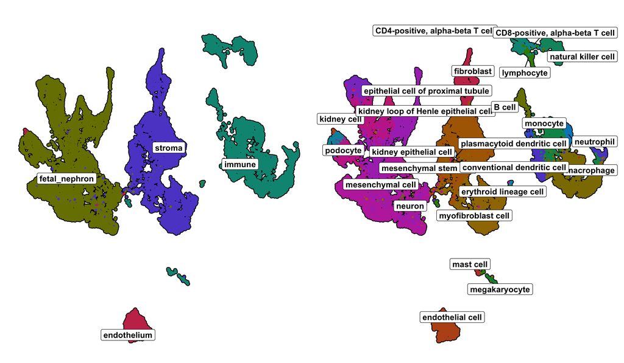

```r
fetal_kidney <- readRDS(params$fetal_kidney_path)

d1 <- do_DimPlot(fetal_kidney, reduction = "umap", dims = c(1, 2), group.by = "compartment", label = TRUE, repel = TRUE) + NoLegend()
d2 <- do_DimPlot(fetal_kidney, reduction = "umap", dims = c(1, 2), group.by = "cell_type", label = TRUE, repel = TRUE) + NoLegend()

d1 | d2
```

## Characterization of compartment and cell types in the reference

Here, we use an unbiased approach to find transcripts that characterized the different compartments and cell types.

This is just to get markers genes of the different population, in case some could be of interest for the Wilms tumor annotations.

We run `DElegate::FindAllMarkers2()` to find markers of the different clusters and manually check if they do make sense. `DElegate::FindAllMarkers2()` is an improved version of `Seurat::FindAllMarkers()` based on pseudobulk differential expression method. Please check the preprint from Hafemeister and Halbritter: https://www.biorxiv.org/content/10.1101/2023.03.28.534443v2 and tool described here: https://github.com/cancerbits/DElegate

### Find marker genes for each of the compartment

```r
de_results <- DElegate::FindAllMarkers2(fetal_kidney, group_column = "compartment", )
# filter the most relevant markers
s.markers <- de_results[de_results$padj < params$padj_threshold & de_results$log_fc > params$lfc_threshold & de_results$rate1 > params$rate1_threshold, ]

DT::datatable(s.markers,
  caption = ("marker genes"),
  extensions = "Buttons",
  options = list(
    dom = "Bfrtip",
    buttons = c("csv", "excel")
  )
)
```

|  | feature | ave_expr | log_fc | stat | pvalue | padj | rate1 | rate2 | group1 | feature_rank |
| --- | --- | --- | --- | --- | --- | --- | --- | --- | --- | --- |
| 1 | ENSG00000172889 | 8.23083836482164 | 4.060520677232768 | 38764.56372543801 | 8.971227808927126e-16 | 5.118934826096773e-13 | 0.9352989352989353 | 0.2456113335386511 | endothelium | 1 |
| 2 | ENSG00000267107 | 6.681530528386308 | 7.922400110867147 | 32928.84765556546 | 1.701291142037112e-15 | 5.118934826096773e-13 | 0.8361998361998362 | 0.01331998768093625 | endothelium | 2 |
| 3 | ENSG00000149564 | 7.631802887765367 | 4.562050635667474 | 32340.07848096086 | 1.825718156370177e-15 | 5.118934826096773e-13 | 0.8746928746928747 | 0.1142978133661842 | endothelium | 3 |
| 4 | ENSG00000249751 | 6.333662829159376 | 7.481039160977764 | 30646.80768971297 | 2.254844693195419e-15 | 5.118934826096773e-13 | 0.7952497952497952 | 0.0162842623960579 | endothelium | 4 |
| 5 | ENSG00000176435 | 5.352363275259406 | 6.848417294292104 | 29564.43411115176 | 2.596210597690084e-15 | 5.118934826096773e-13 | 0.6986076986076986 | 0.01643825069294734 | endothelium | 5 |
| 6 | ENSG00000162407 | 7.537142605753898 | 3.801195733872814 | 28408.94016011012 | 3.034869908095046e-15 | 5.118934826096773e-13 | 0.8206388206388207 | 0.1797043424699723 | endothelium | 6 |
| 7 | ENSG00000163762 | 5.672886305882901 | 7.995456357526643 | 28333.33618257109 | 3.067634573602173e-15 | 5.118934826096773e-13 | 0.719082719082719 | 0.008892824145364952 | endothelium | 7 |
| 8 | ENSG00000131477 | 9.560568726241419 | 4.604274920004793 | 27736.32345231589 | 3.333826901574695e-15 | 5.118934826096773e-13 | 0.9696969696969697 | 0.3086695411148753 | endothelium | 8 |
| 9 | ENSG00000137509 | 9.115787466965932 | 4.197601587293791 | 27392.79209790848 | 3.500791294443082e-15 | 5.118934826096773e-13 | 0.9385749385749386 | 0.3954419464120727 | endothelium | 9 |
| 10 | ENSG00000066056 | 6.577988632025106 | 6.389747354240529 | 26119.62780681159 | 4.219152679784561e-15 | 5.552404926596482e-13 | 0.8083538083538083 | 0.03526331998768094 | endothelium | 10 |

[output cut: 650 more lines]

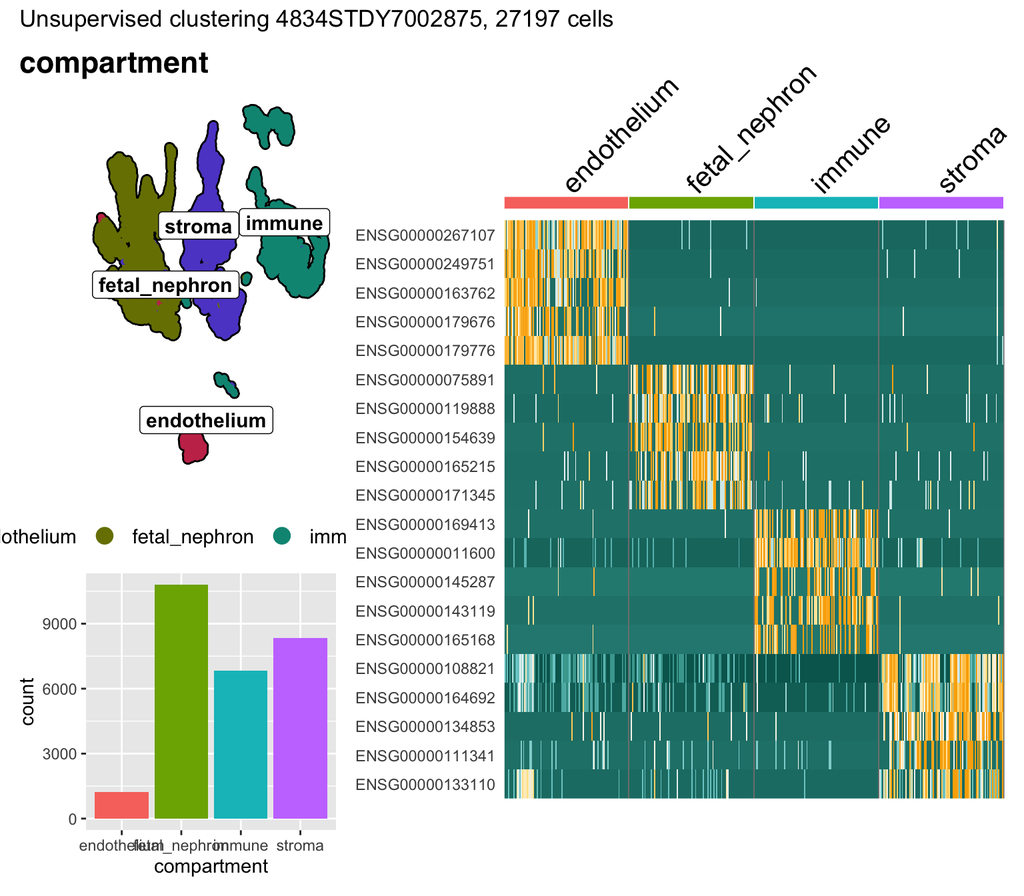

```r
# Select top 5 genes for heatmap plotting
s.markers <- na.omit(s.markers)
s.markers %>%
  group_by(group1) %>%
  top_n(n = 5, wt = log_fc) -> top5

# subset for plotting
Idents(fetal_kidney) <- fetal_kidney$compartment
cells <- WhichCells(fetal_kidney, downsample = 100)
ss <- subset(fetal_kidney, cells = cells)
ss <- ScaleData(ss, features = top5$feature)

p1 <- SCpubr::do_DimPlot(fetal_kidney, reduction = "umap", group.by = "compartment", label = TRUE, repel = TRUE) + ggtitle("compartment")
p2 <- DoHeatmap(ss, features = top5$feature, cells = cells, group.by = "compartment") + NoLegend() +
  scale_fill_gradientn(colors = c("#01665e", "#35978f", "darkslategray3", "#f7f7f7", "#fee391", "#fec44f", "#F9AD03"))
p3 <- ggplot(fetal_kidney@meta.data, aes(compartment, fill = compartment)) +
  geom_bar() +
  NoLegend()


common_title <- sprintf("Unsupervised clustering %s, %d cells", fetal_kidney@meta.data$orig.ident[1], ncol(fetal_kidney))
show((((p1 / p3) + plot_layout(heights = c(3, 2)) | p2)) + plot_layout(widths = c(1, 2)) + plot_layout(heights = c(3, 1)) + plot_annotation(title = common_title))
```

```r
write_csv(de_results, file = file.path(path_to_output, "marker_compartment_fetal_kidney_Stewart.csv"))
```

### Find marker genes for each of the cell types

```r
de_results <- DElegate::FindAllMarkers2(fetal_kidney, group_column = "cell_type")
# filter the most relevant markers
s.markers <- de_results[de_results$padj < params$padj_threshold & de_results$log_fc > params$lfc_threshold & de_results$rate1 > params$rate1_threshold, ]


DT::datatable(s.markers,
  caption = ("marker genes"),
  extensions = "Buttons",
  options = list(
    dom = "Bfrtip",
    buttons = c("csv", "excel")
  )
)
```

|  | feature | ave_expr | log_fc | stat | pvalue | padj | rate1 | rate2 | group1 | feature_rank |
| --- | --- | --- | --- | --- | --- | --- | --- | --- | --- | --- |
| 1 | ENSG00000145423 | 9.690427514909173 | 6.833761069210555 | 55235.60430597315 | 1.178753139536828e-16 | 1.482871449537329e-13 | 0.7684684684684685 | 0.08762985395024342 | fibroblast | 1 |
| 2 | ENSG00000189129 | 9.385051827973607 | 4.760662863252092 | 39137.0322470727 | 4.67982974307256e-16 | 2.94361290839264e-13 | 0.9522522522522523 | 0.2345612757312071 | fibroblast | 2 |
| 3 | ENSG00000011465 | 10.63349414740362 | 5.493124367195522 | 25977.2816331882 | 2.412639383273982e-15 | 1.011700114719556e-12 | 0.9684684684684685 | 0.205887990186683 | fibroblast | 3 |
| 4 | ENSG00000142173 | 8.813359191495165 | 3.140386469030763 | 19978.4050864163 | 6.898683241446546e-15 | 2.169635879434939e-12 | 0.9666666666666667 | 0.3995093341511097 | fibroblast | 4 |
| 5 | ENSG00000113140 | 10.69348647141928 | 3.005206564646911 | 18287.0479163596 | 9.828191515053159e-15 | 2.357150921862836e-12 | 0.9918918918918919 | 0.6448422585962357 | fibroblast | 5 |
| 6 | ENSG00000176046 | 6.674529175231348 | 4.317371281628193 | 17256.98385842804 | 1.239403708357811e-14 | 2.357150921862836e-12 | 0.8522522522522522 | 0.1011998313336144 | fibroblast | 6 |
| 7 | ENSG00000050165 | 5.824697351939689 | 4.797014140088899 | 17014.49274000321 | 1.31161021089347e-14 | 2.357150921862836e-12 | 0.6243243243243243 | 0.06811821980296699 | fibroblast | 7 |
| 8 | ENSG00000116132 | 5.849131011200308 | 7.369160472147762 | 14779.4949193357 | 2.304428416582831e-14 | 3.600729057118742e-12 | 0.7234234234234235 | 0.01188331352781079 | fibroblast | 8 |
| 9 | ENSG00000106333 | 9.14259338786286 | 3.511901659700052 | 14293.14779936736 | 2.633992281618706e-14 | 3.600729057118742e-12 | 0.9495495495495495 | 0.3160578065703224 | fibroblast | 9 |
| 11 | ENSG00000115461 | 10.41334192539788 | 3.924806301350816 | 13646.6092024787 | 3.169830405688635e-14 | 3.600729057118742e-12 | 0.9261261261261261 | 0.2646528922451796 | fibroblast | 11 |

[output cut: 4914 more lines]

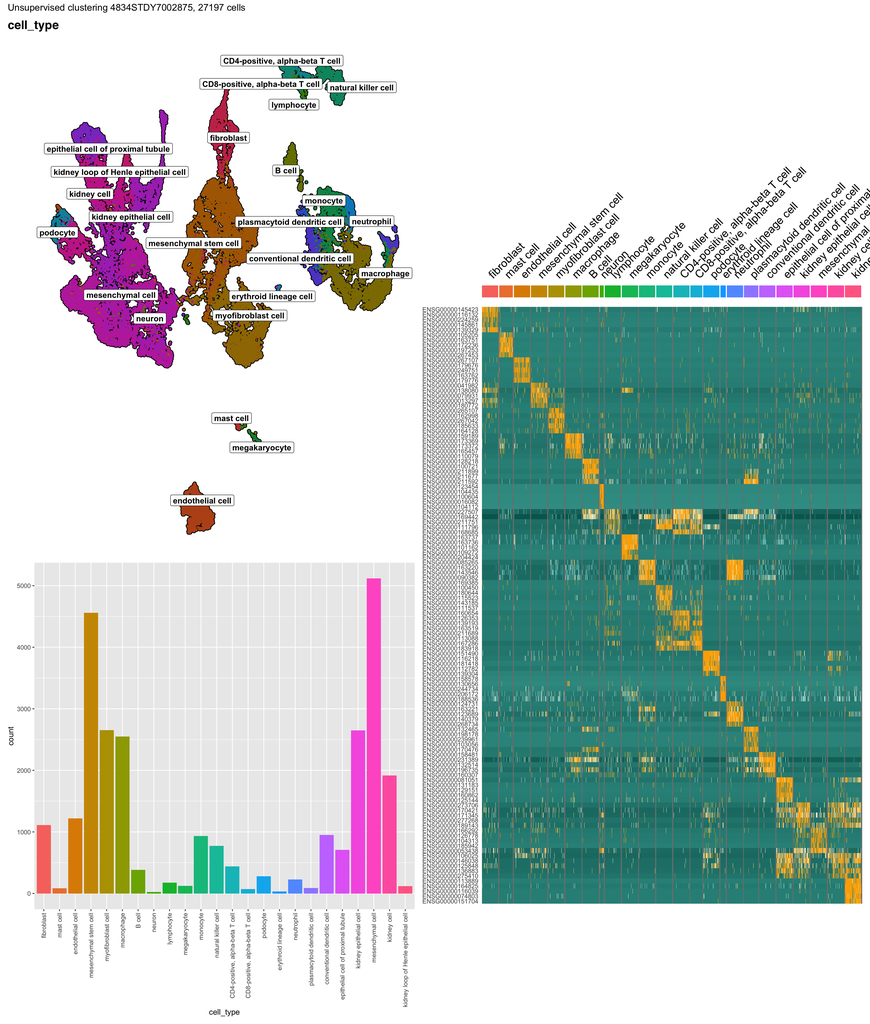

```r
# Select top 5 genes for heatmap plotting
s.markers <- na.omit(s.markers)
s.markers %>%
  group_by(group1) %>%
  top_n(n = 5, wt = log_fc) -> top5

# subset for plotting
Idents(fetal_kidney) <- fetal_kidney$cell_type
cells <- WhichCells(fetal_kidney, downsample = 100)
ss <- subset(fetal_kidney, cells = cells)
ss <- ScaleData(ss, features = top5$feature)

p1 <- SCpubr::do_DimPlot(fetal_kidney, reduction = "umap", group.by = "cell_type", label = TRUE, repel = TRUE) + ggtitle("cell_type") + NoLegend()
p2 <- DoHeatmap(ss, features = top5$feature, cells = cells, group.by = "cell_type") + NoLegend() +
  scale_fill_gradientn(colors = c("#01665e", "#35978f", "darkslategray3", "#f7f7f7", "#fee391", "#fec44f", "#F9AD03"))
p3 <- ggplot(fetal_kidney@meta.data, aes(cell_type, fill = cell_type)) +
  geom_bar() +
  NoLegend() +
  scale_x_discrete(guide = guide_axis(angle = 90))


common_title <- sprintf("Unsupervised clustering %s, %d cells", fetal_kidney@meta.data$orig.ident[1], ncol(fetal_kidney))
show((((p1 / p3) + plot_layout(heights = c(3, 2)) | p2)) + plot_layout(widths = c(1, 1)) + plot_layout(heights = c(3, 1)) + plot_annotation(title = common_title))
```

```r
write_csv(de_results, file = file.path(path_to_output, "marker_cell-type_fetal_kidney_Stewart.csv"))
```

## References

- [1] https://www.science.org/doi/10.1126/science.aat5031